# Regression Models - Introduction - week1

## Regression toward the mean

Sir Francis studied the relationship between heights of parents and their children. His work showed that parents who were taller than average had children who were also tall but closer to the average height. Similarly, parents who were shorter than average had children who were also shorter than average but less so than mom and dad. That is, they were closer to the average height. From one generation to the next the heights moved closer to the average or regressed toward the mean.

Here is a plot of Galton’s data, a set of 928 parent/child height pairs. Moms’ and dads’ heights were averaged together (after moms’ heights were adjusted by a factor of 1.08).

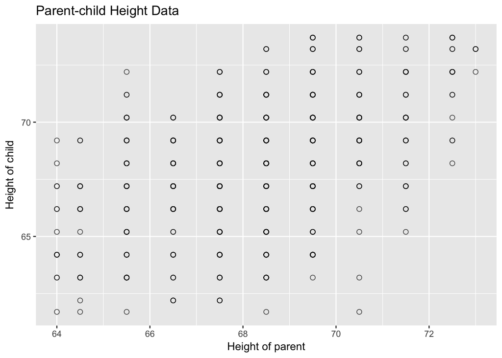

Added a red (45 degree) line of slope 1 and intercept 0 to the plot. If children tended to be the same height as their parents, the data would be expected to vary evenly about this line. This isn’t the case. On the left half of the plot there is a concentration of heights **above** the line, and on the right half we see the concentration **below** the line.

A blue regression line has been added to the plot. This is the line which has the minimum variation of the data around it. Its slope is greater than zero indicating that parents’ heights do affect their children’s. The slope is also less than 1 as would have been the case if children tended to be the same height as their parents.

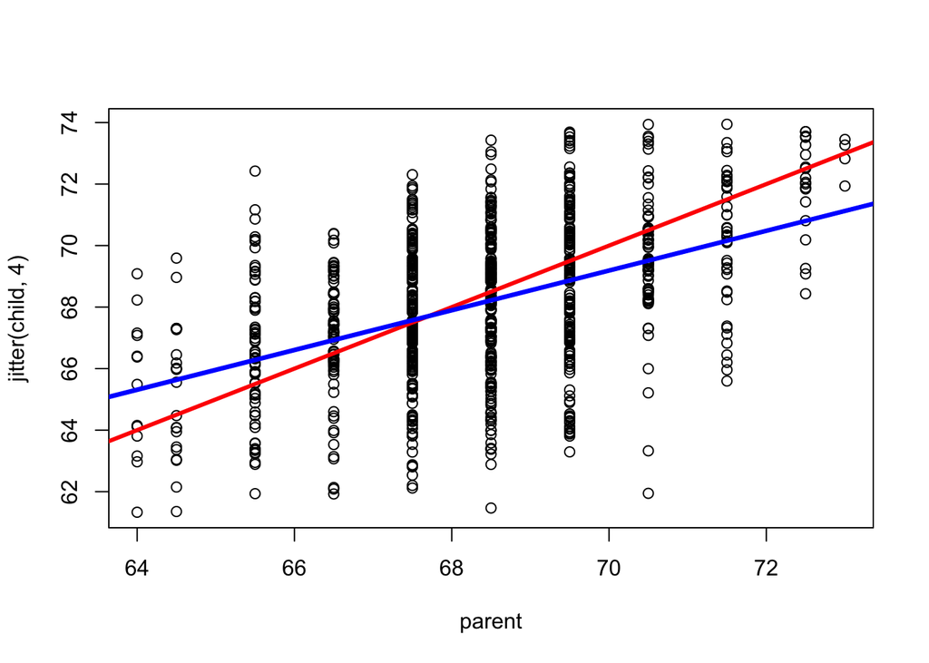

```r
summary(regrline)
```

```
Call:
lm(formula = child ~ parent, data = galton)

Residuals:
    Min      1Q  Median      3Q     Max
-7.8050 -1.3661  0.0487  1.6339  5.9264

Coefficients:
            Estimate Std. Error t value Pr(>|t|)
(Intercept) 23.94153    2.81088   8.517   <2e-16 ***
parent       0.64629    0.04114  15.711   <2e-16 ***
---
Signif. codes:  0 '***' 0.001 '**' 0.01 '*' 0.05 '.' 0.1 ' ' 1

Residual standard error: 2.239 on 926 degrees of freedom
Multiple R-squared:  0.2105,    Adjusted R-squared:  0.2096
F-statistic: 246.8 on 1 and 926 DF,  p-value: < 2.2e-16
```

A coefficient will be within **2 standard errors** of its estimate about 95% of the time. This means the slope of this regression is significantly different than either 0 or 1 since $(.64629) \pm (2*.04114)$ is near neither 0 nor 1.

Now add two yellow lines to indicate the means of the children’s heights (horizontal) and the parents’ (vertical). Note that these lines and the regression line all intersect in a point

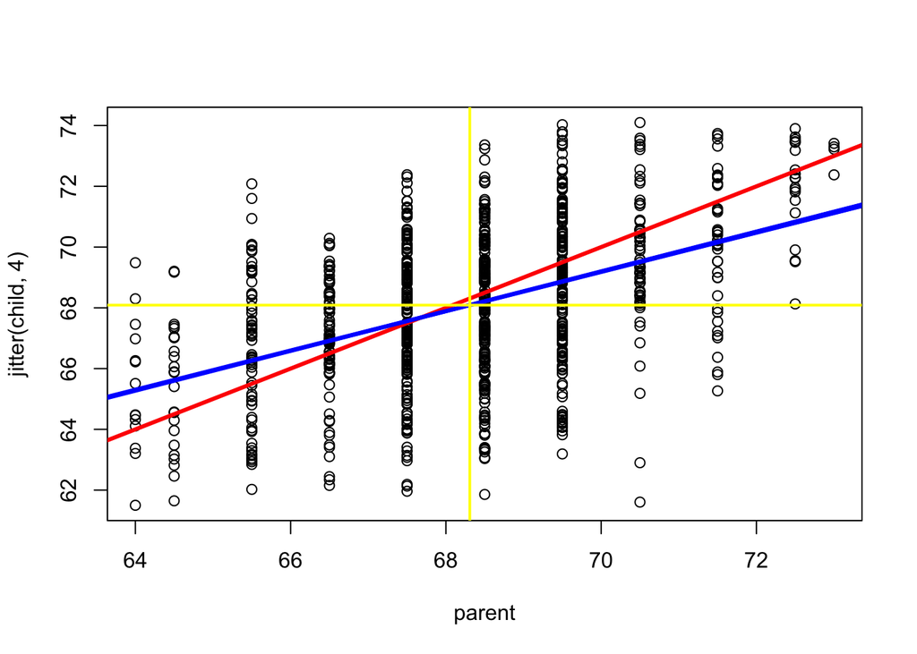

The slope of a line shows how much of a change in the vertical direction is produced by a change in the horizontal direction. So, parents “1 inch” above the mean in height tend to have children who are only .65 inches above the mean.

The green triangle illustrates this point. From the mean, moving a “1 inch distance” horizontally to the right (increasing the parents’ height) produces a “.65 inch” increase in the vertical direction (children’s height).

Similarly, parents who are 1 inch below average in height have children who are only .65 inches below average height. The purple triangle illustrates this.

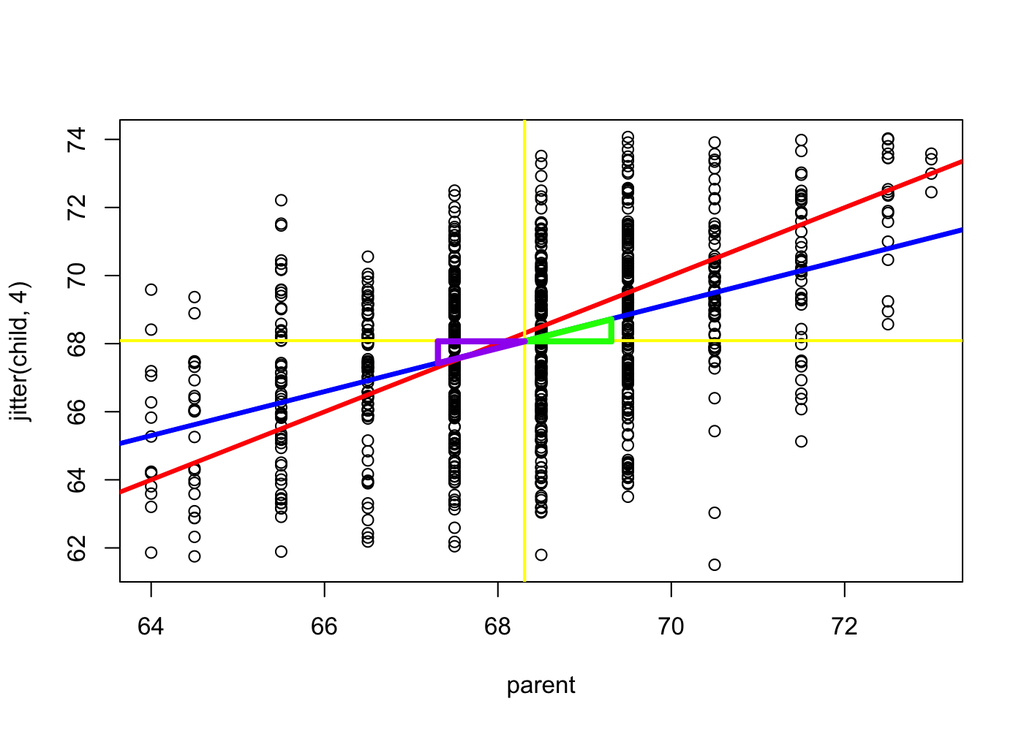